# UNIT13C：類別模型、預測機率與商業決策

預測與決策

中山大學管理學院 第20組

2019-05-27 14:13:39

```r
pacman::p_load(caTools, ggplot2, dplyr)
D = read.csv("data/quality.csv")  # Read in dataset
set.seed(88)
split = sample.split(D$PoorCare, SplitRatio = 0.75)  # split vector
TR = subset(D, split == TRUE)
TS = subset(D, split == FALSE)
glm1 = glm(PoorCare ~ OfficeVisits + Narcotics, TR, family=binomial)
summary(glm1)
```

[output not shown]

### 【A】從預測到決策

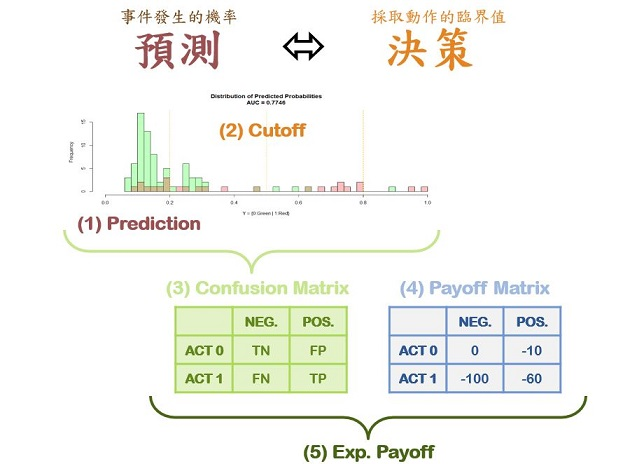

Fig 13.3 - 從預測到決策

### 【B】預測機率分佈 (DPP)

因為這個資料集很小，我們使用全部的資料來做模擬 (通常我們是使用測試資料集)

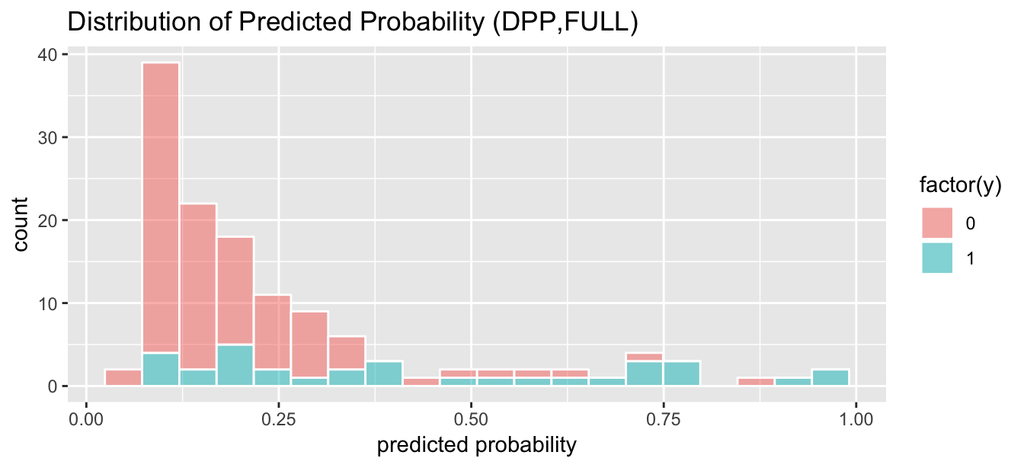

```r
pred = predict(glm1, D, type="response")
y = D$PoorCare
data.frame(pred, y) %>%
  ggplot(aes(x=pred, fill=factor(y))) +
  geom_histogram(bins=20, col='white', position="stack", alpha=0.5) +
  ggtitle("Distribution of Predicted Probability (DPP,FULL)") +
  xlab("predicted probability")
```

### 【C】試算期望報酬

**報酬矩陣 Payoff Matrix**

- TN: NoAction, GoodCare; 沒事
- FN: NoAction, PoorCare; 風險成本很高
- FP: Action, GoodCare; 預防成本
- TP: Action, PoorCare; 預防成本 + 降低後的風險成本

```r
payoff = matrix(c(0,-100,-10,-50),2,2)
payoff
```

```
     [,1] [,2]
[1,]    0  -10
[2,] -100  -50
```

**期望報酬 Expected Payoff**

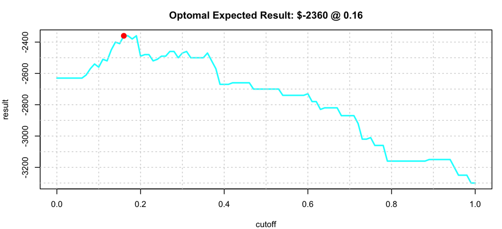

```r
cutoff = seq(0, 1, 0.01)
result = sapply(cutoff, function(p) sum(
  table(factor(y==1, c(F,T)), factor(pred>p, c(F,T))) # confusion matrix
  * payoff ))
i = which.max(result)
par(cex=0.7, mar=c(4,4,3,1))
plot(cutoff, result, type='l', col='cyan', lwd=2, main=sprintf(
  "Optomal Expected Result: $%d @ %.2f",result[i],cutoff[i]))
abline(v=seq(0,1,0.1),h=seq(-6000,0,100),col='lightgray',lty=3)
points(cutoff[i], result[i], pch=20, col='red', cex=2)
```

### 【D】策略模擬

🗿 練習：  
執行`Sim13.R`，先依預設的報酬矩陣回答下列問題：  
【A】 最佳臨界機率是？ 它所對應的期望報酬是多少？  
Ans:機率0.16 期望報酬-2360  
【B】 什麼都不做時，臨界機率和期望報酬各是多少？

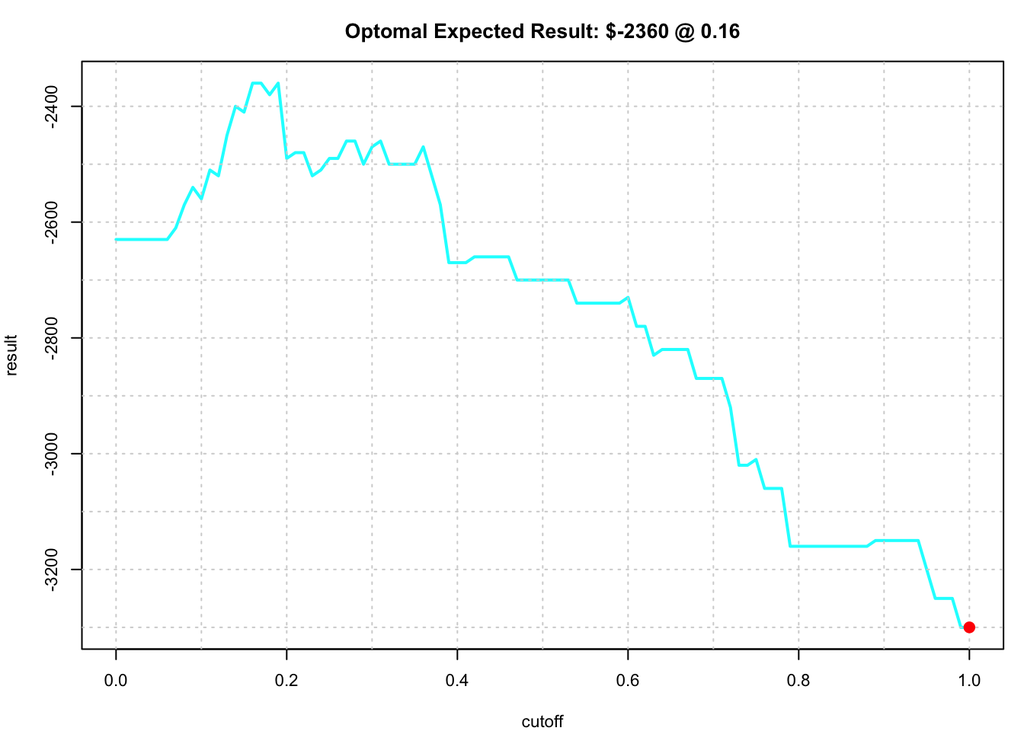

```r
cutoff = seq(0, 1, 0.01)
result = sapply(cutoff, function(p) sum(
  table(factor(y==1, c(F,T)), factor(pred>p, c(F,T))) # confusion matrix
  * payoff ))
i = which.max(result)
par(cex=0.7, mar=c(4,4,3,1))
plot(cutoff, result, type='l', col='cyan', lwd=2, main=sprintf(
  "Optomal Expected Result: $%d @ %.2f",result[i],cutoff[i]))
abline(v=seq(0,1,0.1),h=seq(-6000,0,100),col='lightgray',lty=3)
points(cutoff[101], result[101], pch=20, col='red', cex=2)
```

```r
result[101]#期望報酬
```

```
[1] -3300
```

Ans:機率1，期望報酬-3300  
【C】 每位保戶都做時，臨界機率和期望報酬各是多少？

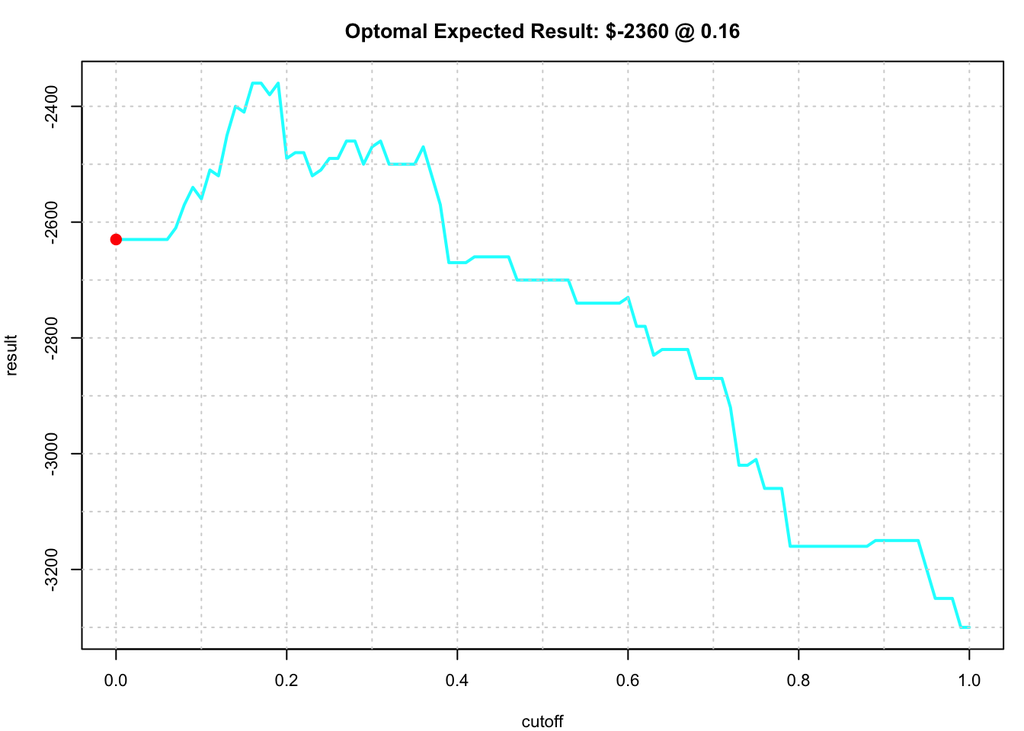

```r
cutoff = seq(0, 1, 0.01)
result = sapply(cutoff, function(p) sum(
  table(factor(y==1, c(F,T)), factor(pred>p, c(F,T))) # confusion matrix
  * payoff ))
i = which.max(result)
par(cex=0.7, mar=c(4,4,3,1))
plot(cutoff, result, type='l', col='cyan', lwd=2, main=sprintf(
  "Optomal Expected Result: $%d @ %.2f",result[i],cutoff[i]))
abline(v=seq(0,1,0.1),h=seq(-6000,0,100),col='lightgray',lty=3)
points(cutoff[1], result[1], pch=20, col='red', cex=2)
```

```r
result[1]#期望報酬
```

```
[1] -2630
```

Ans:機率0，期望報酬-2630  
【D】 以上哪一種做法的期望報酬比較高？  
Ans:對某些人來說是好的，不做跟做的期望報酬都不好。  
【E】 在所有的商務情境都是這種狀況嗎？  
Ans: 若是針對D小題來說，應該是差不多情況的，大部分情況下都會選擇對一些人做，只有少部分情況下才會選擇都做或都不做。  
藉由調整報酬矩陣：  
【F】 模擬出「全不做」比「全做」還要好的狀況  
Ans: TN=0,FN=0,FP=-100,TP=0的情況下，可以模擬出來。  
【G】 並舉出一個會發生這種狀況的商務情境  
Ans: 評估是否針對年輕人執行達文西3D立體為創手術

有五種成本分別為`$5, $10, $15, $20, $30`的介入方法，它們分別可以將風險成本從`$100`降低到`$70, $60, $50, $40, $25` …  
【H】 它們的最佳期望報酬分別是多少？

```r
payoff0 = matrix(c(0,-100,-5,-75),2,2)
payoff0
```

```
     [,1] [,2]
[1,]    0   -5
[2,] -100  -75
```

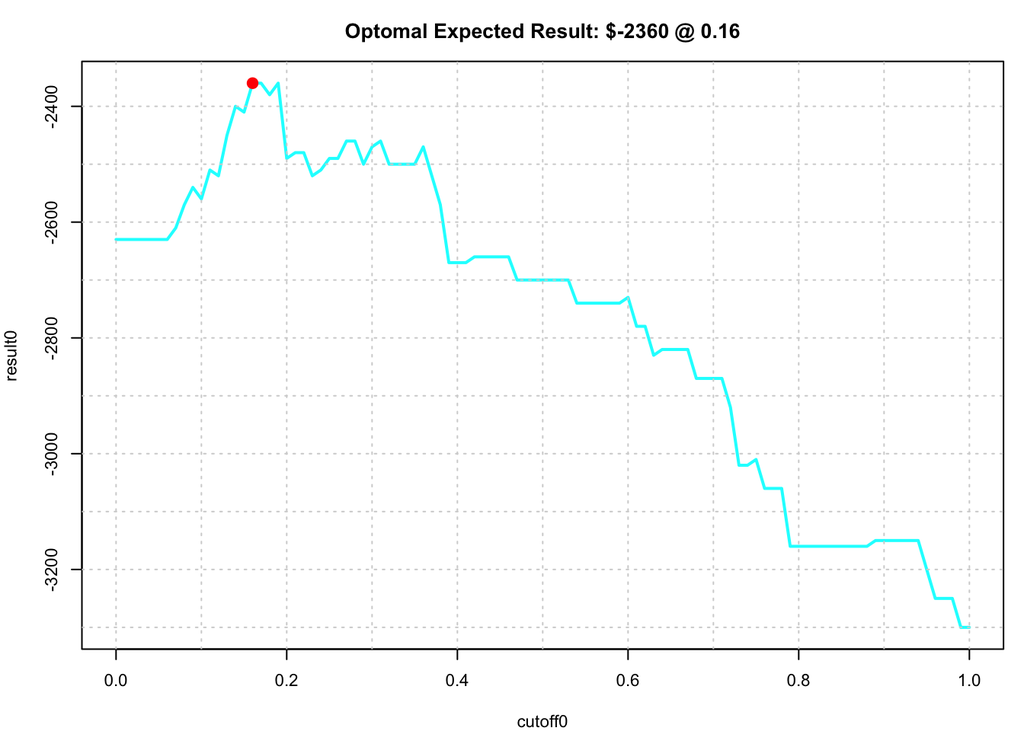

```r
cutoff0 = seq(0, 1, 0.01)
result0 = sapply(cutoff0, function(p) sum(
  table(factor(y==1, c(F,T)), factor(pred>p, c(F,T))) # confusion matrix
  * payoff ))
i = which.max(result0)
par(cex=0.7, mar=c(4,4,3,1))
plot(cutoff0, result0, type='l', col='cyan', lwd=2, main=sprintf(
  "Optomal Expected Result: $%d @ %.2f",result0[i],cutoff0[i]))
abline(v=seq(0,1,0.1),h=seq(-6000,0,100),col='lightgray',lty=3)
points(cutoff0[i], result[i], pch=20, col='red', cex=2)
```

```r
payoff1 = matrix(c(0,-100,-10,-70),2,2)
payoff1
```

```
     [,1] [,2]
[1,]    0  -10
[2,] -100  -70
```

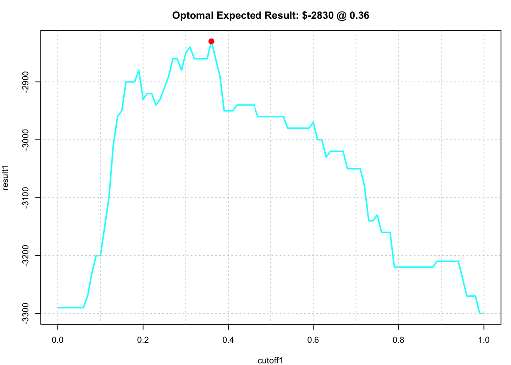

```r
cutoff1= seq(0, 1, 0.01)
result1 = sapply(cutoff1, function(p) sum(
  table(factor(y==1, c(F,T)), factor(pred>p, c(F,T))) # confusion matrix
  * payoff1 ))
i = which.max(result1)
par(cex=0.7, mar=c(4,4,3,1))
plot(cutoff1, result1, type='l', col='cyan', lwd=2, main=sprintf(
  "Optomal Expected Result: $%d @ %.2f",result1[i],cutoff1[i]))
abline(v=seq(0,1,0.1),h=seq(-6000,0,100),col='lightgray',lty=3)
points(cutoff1[i], result1[i], pch=20, col='red', cex=2)
```

Ans:第二種成本的期望報酬為-2830

```r
payoff2 = matrix(c(0,-100,-15,-65),2,2)
payoff2
```

```
     [,1] [,2]
[1,]    0  -15
[2,] -100  -65
```

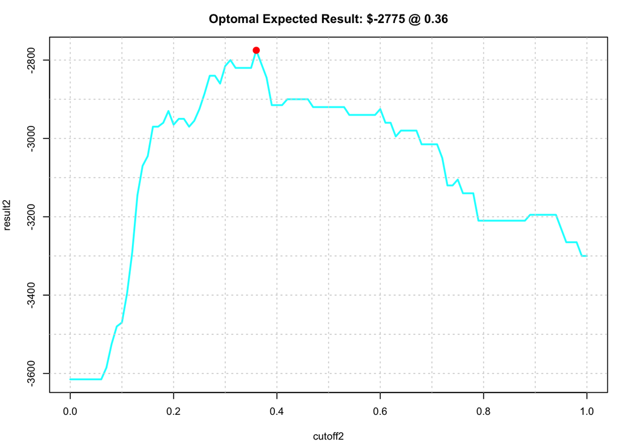

```r
cutoff2 = seq(0, 1, 0.01)
result2 = sapply(cutoff2, function(p) sum(
  table(factor(y==1, c(F,T)), factor(pred>p, c(F,T))) # confusion matrix
  * payoff2 ))
i = which.max(result2)
par(cex=0.7, mar=c(4,4,3,1))
plot(cutoff2, result2, type='l', col='cyan', lwd=2, main=sprintf(
  "Optomal Expected Result: $%d @ %.2f",result2[i],cutoff2[i]))
abline(v=seq(0,1,0.1),h=seq(-6000,0,100),col='lightgray',lty=3)
points(cutoff2[i], result2[i], pch=20, col='red', cex=2)
```

Ans:第三種成本的期望報酬為-2775

```r
payoff3 = matrix(c(0,-100,-20,-60),2,2)
payoff3
```

```
     [,1] [,2]
[1,]    0  -20
[2,] -100  -60
```

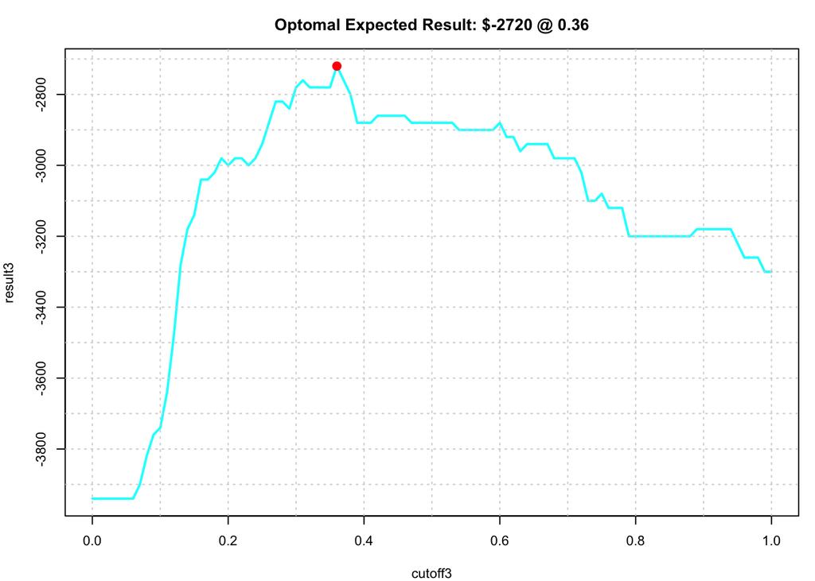

```r
cutoff3 = seq(0, 1, 0.01)
result3 = sapply(cutoff3, function(p) sum(
  table(factor(y==1, c(F,T)), factor(pred>p, c(F,T))) # confusion matrix
  * payoff3 ))
i = which.max(result3)
par(cex=0.7, mar=c(4,4,3,1))
plot(cutoff3, result3, type='l', col='cyan', lwd=2, main=sprintf(
  "Optomal Expected Result: $%d @ %.2f",result3[i],cutoff3[i]))
abline(v=seq(0,1,0.1),h=seq(-6000,0,100),col='lightgray',lty=3)
points(cutoff3[i], result3[i], pch=20, col='red', cex=2)
```

Ans:第四種成本的期望報酬為-2720

```r
payoff4 = matrix(c(0,-100,-30,-55),2,2)
payoff4
```

```
     [,1] [,2]
[1,]    0  -30
[2,] -100  -55
```

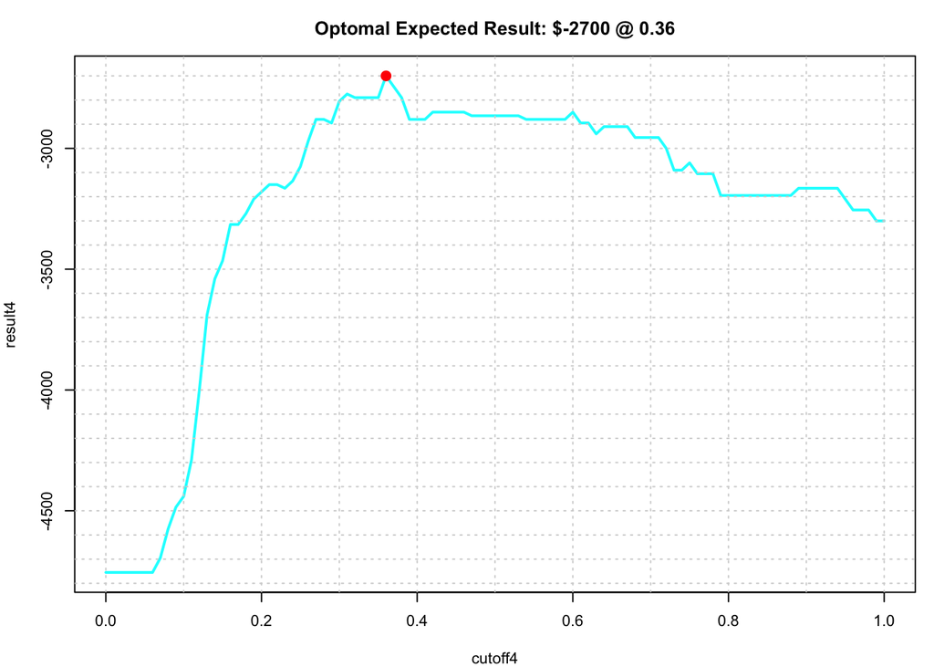

```r
cutoff4 = seq(0, 1, 0.01)
result4 = sapply(cutoff4, function(p) sum(
  table(factor(y==1, c(F,T)), factor(pred>p, c(F,T))) # confusion matrix
  * payoff4 ))
i = which.max(result4)
par(cex=0.7, mar=c(4,4,3,1))
plot(cutoff4, result4, type='l', col='cyan', lwd=2, main=sprintf(
  "Optomal Expected Result: $%d @ %.2f",result4[i],cutoff4[i]))
abline(v=seq(0,1,0.1),h=seq(-6000,0,100),col='lightgray',lty=3)
points(cutoff4[i], result4[i], pch=20, col='red', cex=2)
```

**使用`manipulate`套件做策略模擬**

```r
library(manipulate)
manipulate({
  payoff = matrix(c(TN,FN,FP,TP),2,2)
  cutoff = seq(0, 1, 0.01)
  result = sapply(cutoff, function(p) sum(
    table(factor(y==1, c(F,T)), factor(pred>p, c(F,T))) # confusion matrix
    * payoff ))
  i = which.max(result)
  par(cex=0.7)
  plot(cutoff, result, type='l', col='cyan', lwd=2, main=sprintf(
    "Optomal Expected Result: $%d @ %.2f",result[i],cutoff[i]))
  abline(v=seq(0,1,0.1),h=seq(-10000,0,100),col='lightgray',lty=3)
  points(cutoff[i], result[i], pch=20, col='red', cex=2)
  },
  TN = slider(-100,0,   0,step=5),
  FN = slider(-100,0,-100,step=5),
  FP = slider(-100,0, -10,step=5),
  TP = slider(-100,0, -50,step=5)
  )
```